# Modeling and App Development: Philadelphia Curbs

Samriddhi Khare, Michael Dunst, Ling Chen, Tiffany Luo, Shengqian Wang

2024-04-09

# 1 Data Preparation

# 2 Data Modeling

Simplified Panel with time, road network, and nearest neighbors variables.

## 2.1 Hyper Parameters

mtry=30, ntree = 700, nodesize = 5,maxnodes = 20

## 2.2 Random Forest Model

```r
train_set_simple<- train_set_simple%>%
  select(-SmartZoneName,-curb_zone_id,-week,-day,-geometry)
tuneGrid <- expand.grid(.mtry = best_mtry_2)
fit_rf_simple <- train(bookings~.,
    train_set_simple,
    method = "rf",
    metric = "RMSE",
    tuneGrid = tuneGrid,
    trControl = trControl,
    importance = TRUE,
    ntree = 700,
    nodesize = 5,
    maxnodes = 20)

varImp(fit_rf_simple)
```

```
## rf variable importance
##
##   only 20 most important variables shown (out of 41)
##
##                   Overall
## Weekend_dummy     100.000
## dist_class_4       34.380
## dist_class_1       14.857
## dining_nn1         12.132
## dist_class_3       11.251
## civic_nn1          10.479
## housing_nn1         8.809
## housing_nn2         8.581
## retail_nn1          8.405
## school_nn1          8.122
## parking_nn2         7.404
## quick_grocery_nn1   7.318
## retail_nn3          7.200
## quick_grocery_nn2   7.063
## dist_class_2        6.856
## parking_nn3         6.848
## parking_nn1         6.797
## retail_nn2          6.055
## dining_nn2          5.698
## housing_nn3         5.662
```

```r
prediction <-predict(fit_rf_simple, test_set_simple)
```

The chart visualizes the relative importance of the top 20 variables in a predictive model. Notably, the ‘Weekend_dummy’ variable stands out as the most significant predictor, followed by the distance to class 4 and class 1 roads, indicating their substantial influence on the model’s output. Other proximity-related variables such as dining, housing, parking, retail, quick grocery, civic amenities, and schools are also identified as key factors, though to a lesser extent than weekend and road class variables.

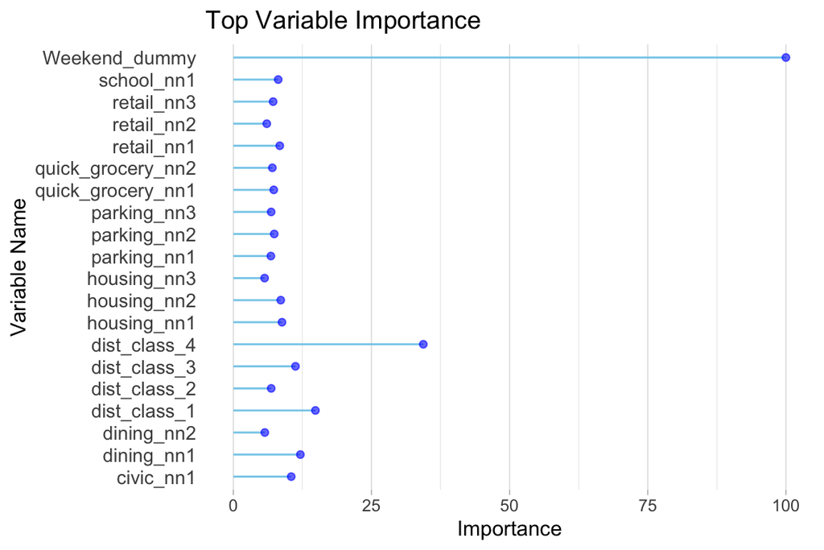

```r
top_n <- 20

ImpData <- as.data.frame(varImp(fit_rf_simple)$importance)
ImpData$Var.Names <- row.names(ImpData)

# Sort by importance, and take the top 'top_n' most important variables
ImpDataTop <- ImpData %>%
  top_n(top_n, Overall) %>%
  arrange(desc(Overall))

# Use the filtered data frame to create a chart
ggplot(ImpDataTop, aes(x=Var.Names, y=Overall)) +
  geom_segment(aes(x=Var.Names, xend=Var.Names, y=0, yend=Overall), color="skyblue") +
  geom_point(aes(y=Overall), color="blue", alpha=0.6) +  # Plot points using the Overall column
  theme_light() +
  coord_flip() +  # Display variable names on the y-axis
  theme(
    legend.position="none",  # Remove legend
    panel.grid.major.y = element_blank(),
    panel.border = element_blank(),
    axis.ticks.y = element_blank(),
    axis.text.y = element_text(size = 10)  # Adjust font size
  ) +
  labs(x = "Variable Name", y = "Importance", title = "Top Variable Importance")
```

```r
# Assuming 'prediction' contains your model's predictions and 'test_set' is your test dataset
# Add a residuals column to test_set
test_set_simple <- test_set_simple %>%
  mutate(
    Prediction = prediction,
    Residual = bookings - Prediction,
    AbsResidual = abs(Residual)
  )
#write_csv(test_set_simple,"./testresult.csv")
```

# 3 Model Generalizability Evaluation

## 3.1 Examine Error Metrics for Accuracy

The provided chart showcases the performance of a Random Forest model used for predicting bookings on a weekly basis. It indicates that the model tends to underperform particularly in extreme scenarios, such as when bookings are unusually high or low. The model shows a noticeable disparity in predictive accuracy for bookings that exceed an average of 5, often underestimating the actual values. Additionally, there’s an observable seasonal trend in bookings, which the model does not seem to fully capture. This limitation is likely due to the model being trained on a dataset limited to the months of October through April, which may not be representative of the entire year. This seasonal effect and the limited data scope could be contributing to the model’s reduced effectiveness during peak booking periods in summer.

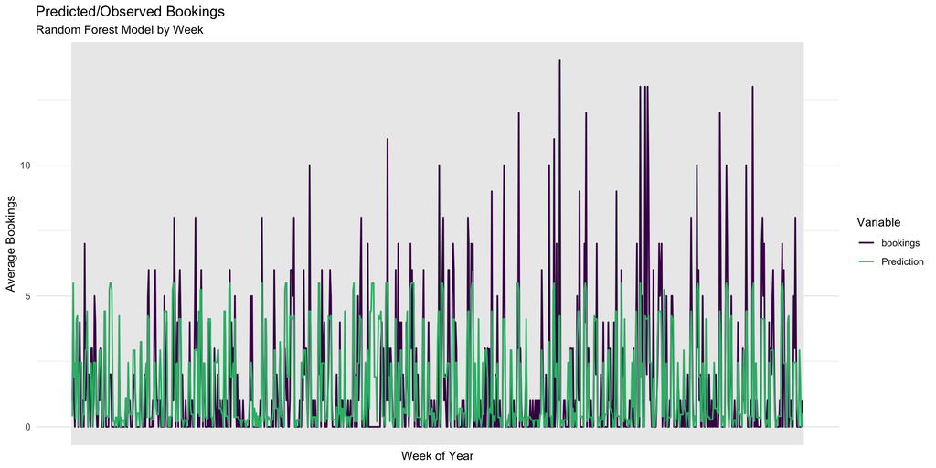

```r
# add a 'year' variable to distinguish between years, then create an 'ordered_week' variable for proper week ordering.
test_set_simple <- test_set_simple %>%
  mutate(year = if_else(week >= 42, "2022", "2023")) %>%  # Assign "Year1" or "Year2" based on the week number
  arrange(year, week) %>%  # Sort by year and week
  mutate(ordered_week = row_number())  # Assign a unique ordering number for each week

# Now use this 'ordered_week' variable to draw your plot
test_set_simple %>%
  select(SmartZoneName, ordered_week, day, bookings, Prediction) %>%
  gather(Variable, Value, bookings, Prediction) %>%  # Transform data to long format for plotting
  group_by(Variable, ordered_week, day) %>%
  summarize(Value = mean(Value, na.rm = TRUE), .groups = 'drop') %>%  # Calculate average value for each group
  ggplot(aes(x = ordered_week, y = Value, color = Variable, group = Variable)) +  # Plotting
    geom_line(size = 0.7) +
  scale_color_manual(values = c("bookings" = "#440154", "Prediction" = "#35B779")) +
    scale_x_continuous(breaks = test_set_simple$ordered_week, labels = test_set_simple$week) +  # Custom x-axis breaks and labels
    labs(title = "Predicted/Observed Bookings",
         subtitle = "Random Forest Model by Week",
         x = "Week of Year",
         y = "Average Bookings") +  # Labels and titles
    theme_minimal() +  # Minimal theme
    theme(axis.text.x = element_blank()  # Hide x-axis text
    )
```

```r
    #theme(axis.text.x = element_text(angle = 90, vjust = 0.5))  # Adjust the appearance of x-axis text
```

## 3.2 Space-Time Error Evaluation

```r
error_analysis_curb <- test_set_simple %>%
  group_by(SmartZoneName,CLASS_2) %>%
  summarise(
    MeanResidual = mean(Residual, na.rm = TRUE),
    MeanAbsResidual = mean(AbsResidual, na.rm = TRUE),
    MSE = mean(Residual^2, na.rm = TRUE),
    Count = n()
  ) %>%
  arrange(desc(MeanAbsResidual))
```

This map provides a spatial overview of the model’s performance across different streets, where larger circles indicate a higher MAE at that curb, suggesting that the model’s predictions are less accurate on Chestnut St, while Walnut St has a better performance.

```r
# Now group by SmartZoneName and summarize the residuals

error_analysis_curb <- test_set_simple %>%
  group_by(SmartZoneName, CLASS_2) %>%
  summarise(
    MeanResidual = mean(Residual, na.rm = TRUE),  # 平均误差
    MAE = mean(AbsResidual, na.rm = TRUE),  # 平均绝对误差（MAE）
    MSE = mean(Residual^2, na.rm = TRUE),  # 均方误差
    RMSE = sqrt(MSE),  # 均方根误差
    Count = n(),  # 计数
    .groups = "drop"  # 防止之后版本的 dplyr 报错
  ) %>%
  arrange(desc(MAE))

# View the error analysis results
print(error_analysis_curb)
```

```
## # A tibble: 22 × 7
##    SmartZoneName                   CLASS_2 MeanResidual   MAE    MSE  RMSE Count
##    <chr>                             <int>        <dbl> <dbl>  <dbl> <dbl> <int>
##  1 1200 Chestnut St (near 13 St)         2      -0.560  2.97  12.8   3.57     59
##  2 1000 Chestnut St (near 11 St)         2       0.258  2.65  10.4   3.22     53
##  3 1300 Chestnut Street (near Bro…       2       0.533  2.20   9.05  3.01     66
##  4 900 Chestnut St (near 10 St)          2       0.147  1.62   4.13  2.03     59
##  5 800 Chestnut St (near 8 St)           2       0.0450 1.47   3.19  1.78     59
##  6 1200 Sansom Street (near 13 St…       3       0.345  1.36   3.17  1.78     50
##  7 1200 Sansom Street (near 12 St…       3      -0.464  0.919  1.52  1.23     50
##  8 100 Broad (near Walnut St)            2       0.404  0.588  1.63  1.28      9
##  9 600 Chestnut St (near 6 Street)       2       0.0850 0.547  0.806 0.898     6
## 10 900 Walnut Street (near 10 Str…       2       0.0166 0.519  0.591 0.769    52
## # ℹ 12 more rows
```

```r
geo <- geo %>%
  select(SmartZoneName,geometry)%>%
  distinct(SmartZoneName, geometry)

geo_points <- geo$geometry %>%
  stringr::str_extract_all("[-]?[0-9]+\\.[0-9]+") %>% # 提取所有数字（包括小数点和负号）
  purrr::map(~st_point(as.numeric(.x), dim = "XY")) # 将每个提取出来的数值向量转换为POINT对象

geo_sf <- st_as_sf(geo, geometry = do.call("st_sfc", geo_points), crs = 4326) %>% # crs 4326是WGS84坐标系
  select(-geometry)

error_analysis_curb <- geo_sf %>%
  left_join(error_analysis_curb, by=c("SmartZoneName"))

# Set tmap mode to view for interactive maps
tmap_mode("view")
```

```
## tmap mode set to interactive viewing
```

```r
tm <- tm_shape(error_analysis_curb) +
  tm_bubbles(size = "MAE", col = "MAE", palette = "viridis", scale=5, border.col = "black",
             title.size = "MAE", title.col = "MAE")
tm
```

```
## Legend for symbol sizes not available in view mode.
```

[interactive chart not shown]

From the chart, the high error in conjunction with high data counts suggest a systematic issue with the model especially on Monday, rather than a random fluctuation. As such, there’s need to further check the weekly patterns or specific events impacting the model performance. While those low-low points, like Sunday, demonstrate its good performance on weekends.

```r
# Now group by SmartZoneName and summarize the residuals
error_analysis_day <- test_set_simple %>%
  group_by(day) %>%
  summarise(
    MeanResidual = mean(Residual, na.rm = TRUE),
    MAE = mean(AbsResidual, na.rm = TRUE),
    MSE = mean(Residual^2, na.rm = TRUE),
    Count = n()
  ) %>%
  arrange(desc(MAE))

# View the error analysis results
print(error_analysis_day)
```

```
## # A tibble: 7 × 5
##   day   MeanResidual   MAE   MSE Count
##   <chr>        <dbl> <dbl> <dbl> <int>
## 1 Wed         0.0403 1.24   3.47   115
## 2 Thu         0.119  1.21   3.22   121
## 3 Mon        -0.328  1.10   2.34   136
## 4 Fri         0.118  1.09   3.18   130
## 5 Tue        -0.109  1.09   2.38   130
## 6 Sun        -0.185  0.867  3.18   118
## 7 Sat         0.411  0.826  3.56   141
```

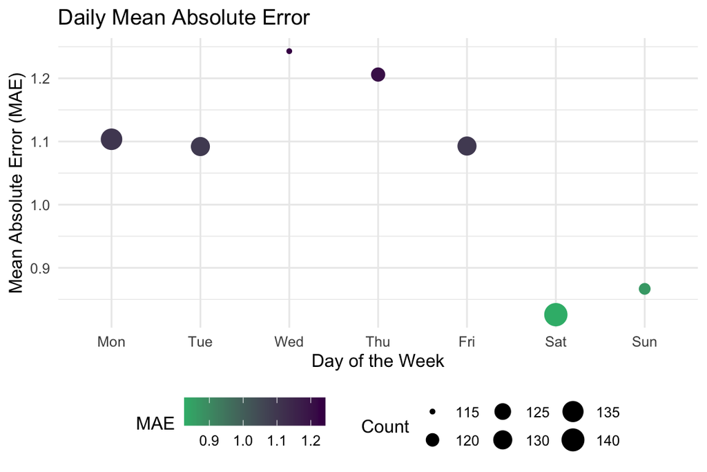

```r
error_analysis_day$day <- factor(error_analysis_day$day,
                                 levels = c("Mon", "Tue", "Wed", "Thu", "Fri", "Sat", "Sun"),
                                 ordered = TRUE)


ggplot(error_analysis_day, aes(x = day, y = MAE)) +
  geom_point(aes(size = Count, color = MAE)) +
  scale_color_gradient(low = "#35B779", high = "#440154") +
  labs(x = "Day of the Week",
       y = "Mean Absolute Error (MAE)",
       title = "Daily Mean Absolute Error") +
  theme_minimal() +
  theme(legend.position = "bottom")
```

```r
# Now group by SmartZoneName and summarize the residuals
error_analysis_weekend <- test_set_simple %>%
  group_by(Weekend_dummy) %>%
  summarise(
    MeanResidual = mean(Residual, na.rm = TRUE),
    MAE = mean(AbsResidual, na.rm = TRUE),
    MSE = mean(Residual^2, na.rm = TRUE),
    Count = n()
  ) %>%
  arrange(desc(MAE))

# View the error analysis results
print(error_analysis_weekend)
```

```
## # A tibble: 2 × 5
##   Weekend_dummy MeanResidual   MAE   MSE Count
##           <int>        <dbl> <dbl> <dbl> <int>
## 1             0      -0.0386 1.14   2.90   632
## 2             1       0.139  0.844  3.39   259
```

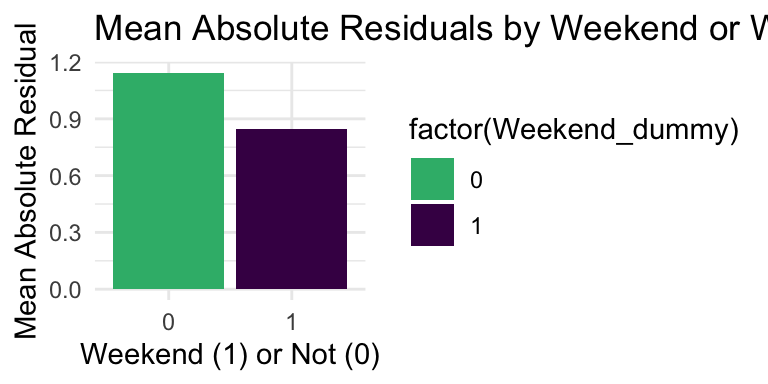

```r
ggplot(error_analysis_weekend, aes(x = factor(Weekend_dummy), y = MAE)) +
  geom_bar(stat = "identity", aes(fill = factor(Weekend_dummy))) +
  scale_fill_manual(values = c("#35B779", "#440154")) +
  labs(x = "Weekend (1) or Not (0)", y = "Mean Absolute Residual",
       title = "Mean Absolute Residuals by Weekend or Weekday") +
  theme_minimal()
```

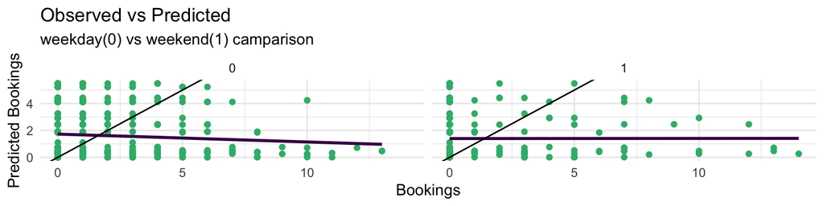

```r
ggplot()+
  geom_point(data = test_set_simple,aes(x= bookings, y = prediction),color = "#35B779")+
    geom_smooth(data = test_set_simple,aes(x= bookings, y= prediction), method = "lm", se = FALSE, color = '#440154')+
    geom_abline(slope = 1, intercept = 0)+
  facet_grid(~Weekend_dummy)+
  labs(title="Observed vs Predicted",
       subtitle = 'weekday(0) vs weekend(1) camparison',
       x="Bookings",
       y="Predicted Bookings")+
  plotTheme()+
  theme_minimal()
```

## 3.3 Cross-validation

```r
fitControl <- trainControl(method = "cv", number = 50)
set.seed(825)

rf.cv <- train(bookings ~ ., data = train_set_simple,
               method = "rf",
               trControl = fitControl,
               tuneGrid = expand.grid(.mtry = best_mtry_2),
               importance = TRUE,
               ntree = 700,
               nodesize = 5,
               maxnodes = 20)

rf.cv
```

```
## Random Forest
##
## 2077 samples
##   41 predictor
##
## No pre-processing
## Resampling: Cross-Validated (50 fold)
## Summary of sample sizes: 2035, 2035, 2036, 2036, 2035, 2035, ...
## Resampling results:
##
##   RMSE     Rsquared   MAE
##   1.50974  0.5737692  0.9467906
##
## Tuning parameter 'mtry' was held constant at a value of 30
```

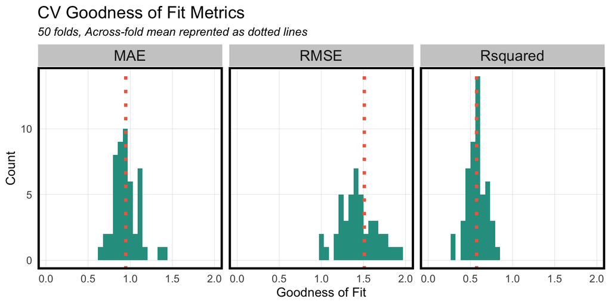

```r
dplyr::select(rf.cv$resample, -Resample) %>%
  gather(metric, value) %>%
  left_join(gather(rf.cv$results[2:4], metric, mean)) %>%
  ggplot(aes(value)) +
    geom_histogram(bins=35, fill = "#2a9d8f") +
    facet_wrap(~metric) +
    geom_vline(aes(xintercept = mean), colour = "#e76f51", linetype = 3, size = 1.5) +
    scale_x_continuous(limits = c(0, 2)) +
    labs(x="Goodness of Fit", y="Count", title="CV Goodness of Fit Metrics",
         subtitle = "50 folds, Across-fold mean reprented as dotted lines") +
    plotTheme()
```